# NaiveBayes_Tf_Idf_Unigram_and_Bigram (5)

## **3. Naive Bayes model using TF-IDF Vectors for Unigram+Bigram**

Config of the model trained

Train Time = 0.13 seconds

Training Data Check

Confusion Matrix Built - Yes

F1 Score for Positive = 0.93

F1 Score for Negative = 0.85

AUC plotted - Yes

Accuracy computed - Yes

Accuracy = 0.88

Feature Engg

Interpretability

2 interesting findings?

Testing Data Check

Confusion Matrix Built - Yes

F1 Score for Positive = 0.90

F1 Score for Negative = 0.79

AUC plotted - Yes

AUC = 0.91

Accuracy computed - Yes

Accuracy = 0.83

Prompts Used :

1. Start : Naive Bayes model using TF-IDF Vectors for Unigram+Bigram
2. End : what is hstack in the code doing

**Importing Libraries**

```python
import re
import nltk
import numpy as np
import pandas as pd
import nltk
import matplotlib.pyplot as plt
from sklearn.model_selection import GridSearchCV, cross_val_score
from nltk.corpus import stopwords
from nltk.tokenize import word_tokenize
from nltk.stem import WordNetLemmatizer
from sklearn.feature_extraction.text import TfidfVectorizer
from sklearn.model_selection import train_test_split
from sklearn.naive_bayes import MultinomialNB
from sklearn.metrics import accuracy_score, classification_report, precision_score, recall_score, confusion_matrix
import seaborn as sns
from scipy.sparse import hstack
import time
from sklearn.metrics import f1_score, roc_auc_score, roc_curve, auc
from sklearn.preprocessing import label_binarize
from imblearn.over_sampling import SMOTE
from imblearn.combine import SMOTEENN
```

```python
nltk.download('punkt')
nltk.download('wordnet')
nltk.download('stopwords')
nltk.download('punkt_tab')
```

```
True
```

```python
df = pd.read_csv('/content/yelp_sample_20k.csv')
```

```python
df
```

|  | text | stars |
| --- | --- | --- |
| 0 | We really enjoyed their use of homemade ingred... | 5.0 |
| 1 | We moved to Sarasota and upon many recommendat... | 5.0 |
| 2 | Very disappointed in today's meal. The wife an... | 2.0 |
| 3 | I wish I could reward the store w 5 stars, pro... | 4.0 |
| 4 | Came here for brunch yesterday, it goes till 3... | 5.0 |
| ... | ... | ... |
| 19995 | One of the worst before dinner experiences I h... | 1.0 |
| 19996 | This place is magical. It's perfect for weddin... | 5.0 |
| 19997 | to the person that hit my brand new car yester... | 2.0 |
| 19998 | Lilly's is one of the best places to go for lu... | 5.0 |
| 19999 | I didn't think it'd happen, but I've finally f... | 4.0 |

20000 rows × 2 columns

```python
df.describe()
```

|  | stars |
| --- | --- |
| count | 20000.000000 |
| mean | 3.756850 |
| std | 1.475919 |
| min | 1.000000 |
| 25% | 3.000000 |
| 50% | 4.000000 |
| 75% | 5.000000 |
| max | 5.000000 |

```python
df.info()
```

```
<class 'pandas.core.frame.DataFrame'>
RangeIndex: 20000 entries, 0 to 19999
Data columns (total 2 columns):
 #   Column  Non-Null Count  Dtype
---  ------  --------------  -----
 0   text    20000 non-null  object
 1   stars   20000 non-null  float64
dtypes: float64(1), object(1)
memory usage: 312.6+ KB
```

**Data Preprocessing**

```python
def convert_stars_to_sentiment(stars):
    if stars <= 2:
        return 0  # Negative
    elif stars == 3:
        return 1  # Neutral
    else:
        return 2  # Positive
```

```python
df['sentiment'] = df['stars'].apply(convert_stars_to_sentiment)
```

```python
df
```

|  | text | stars | sentiment |
| --- | --- | --- | --- |
| 0 | We really enjoyed their use of homemade ingred... | 5.0 | 2 |
| 1 | We moved to Sarasota and upon many recommendat... | 5.0 | 2 |
| 2 | Very disappointed in today's meal. The wife an... | 2.0 | 0 |
| 3 | I wish I could reward the store w 5 stars, pro... | 4.0 | 2 |
| 4 | Came here for brunch yesterday, it goes till 3... | 5.0 | 2 |
| ... | ... | ... | ... |
| 19995 | One of the worst before dinner experiences I h... | 1.0 | 0 |
| 19996 | This place is magical. It's perfect for weddin... | 5.0 | 2 |
| 19997 | to the person that hit my brand new car yester... | 2.0 | 0 |
| 19998 | Lilly's is one of the best places to go for lu... | 5.0 | 2 |
| 19999 | I didn't think it'd happen, but I've finally f... | 4.0 | 2 |

20000 rows × 3 columns

**Data Cleaning**

```python
def preprocess_text(text):
    text = text.lower()
    text = re.sub(r'http\S+|www\S+', '', text) #For Removing URL
    text = re.sub(r'@\w+', '', text ) #For Removing Mentions
    text = re.sub(r'[^a-zA-Z\s]', '', text) #For removing special characters
    tokens = word_tokenize(text)
    lemmatizer = WordNetLemmatizer()
    tokens = [lemmatizer.lemmatize(token) for token in tokens]
    stop_words = set(stopwords.words('english'))
    tokens = [token for token in tokens if token not in stop_words]
    return ' '.join(tokens)
```

```python
df['clean_text'] = df['text'].apply(preprocess_text)
```

```python
df
```

|  | text | stars | sentiment | clean_text |
| --- | --- | --- | --- | --- |
| 0 | We really enjoyed their use of homemade ingred... | 5.0 | 2 | really enjoyed use homemade ingredient really ... |
| 1 | We moved to Sarasota and upon many recommendat... | 5.0 | 2 | moved sarasota upon many recommendation decide... |
| 2 | Very disappointed in today's meal. The wife an... | 2.0 | 0 | disappointed today meal wife got pasta dish wa... |
| 3 | I wish I could reward the store w 5 stars, pro... | 4.0 | 2 | wish could reward store w star product marketi... |
| 4 | Came here for brunch yesterday, it goes till 3... | 5.0 | 2 | came brunch yesterday go till pm great late ri... |
| ... | ... | ... | ... | ... |
| 19995 | One of the worst before dinner experiences I h... | 1.0 | 0 | one worst dinner experience ever local recomme... |
| 19996 | This place is magical. It's perfect for weddin... | 5.0 | 2 | place magical perfect wedding business dinner ... |
| 19997 | to the person that hit my brand new car yester... | 2.0 | 0 | person hit brand new car yesterday right front... |
| 19998 | Lilly's is one of the best places to go for lu... | 5.0 | 2 | lillys one best place go lunch doylestown alwa... |
| 19999 | I didn't think it'd happen, but I've finally f... | 4.0 | 2 | didnt think itd happen ive finally found anoth... |

20000 rows × 4 columns

```python
df.sentiment.info()
```

```
<class 'pandas.core.series.Series'>
RangeIndex: 20000 entries, 0 to 19999
Series name: sentiment
Non-Null Count  Dtype
--------------  -----
20000 non-null  int64
dtypes: int64(1)
memory usage: 156.4 KB
```

Custom Feature Engineering Function

```python
def get_sentence_length(text):
    return len(text.split())

def get_word_density(text):
    words = text.split()
    return len(set(words)) / len(words) if len(words) > 0 else 0

def count_punctuation(text):
    return sum(1 for char in text if char in ".,!?")

def count_stopwords(text):
    return sum(1 for word in text.split() if word in stopwords.words('english'))
```

```python
# Apply feature engineering
df['sentence_length'] = df['clean_text'].apply(get_sentence_length)
df['word_density'] = df['clean_text'].apply(get_word_density)
df['punctuation_count'] = df['clean_text'].apply(count_punctuation)
df['stopword_count'] = df['clean_text'].apply(count_stopwords)
```

```python
X_features = df[['sentence_length', 'word_density', 'punctuation_count', 'stopword_count']].values
```

```python
y = np.array(df['sentiment'])
X_train, X_test, y_train, y_test = train_test_split(df['clean_text'], y, test_size=0.2, random_state=42)
```

```python
vectorizer = TfidfVectorizer(
    ngram_range=(1, 2),  # Unigrams & Bigrams
    max_features=10000,   # Limit vocabulary
    min_df=3,            # Ignore rare words
    sublinear_tf=True,   #scales the term frequency (TF) using a logarithmic function instead of using raw counts which helps to improve neatral class improvement.
    max_df=0.9
)
X_train_tfidf = vectorizer.fit_transform(X_train)
X_test_tfidf = vectorizer.transform(X_test)
```

```python
start_time = time.time()
```

```python
nb_model = MultinomialNB(alpha= 0.1)
nb_model.fit(X_train_tfidf, y_train)
```

```
MultinomialNB(alpha=0.1)
```

```python
y_train_pred = nb_model.predict(X_train_tfidf)

# Testing Accuracy
y_test_pred = nb_model.predict(X_test_tfidf)
y_train_prob = nb_model.predict_proba(X_train_tfidf)
y_prob = nb_model.predict_proba(X_test_tfidf)
```

```python
#  Compute Evaluation Metrics
train_accuracy = accuracy_score(y_train, y_train_pred)
test_accuracy = accuracy_score(y_test, y_test_pred)
precision = precision_score(y_test, y_test_pred, average='weighted')
recall = recall_score(y_test, y_test_pred, average='weighted')
report = classification_report(y_test, y_test_pred, output_dict=True)
f1_positive_train = f1_score(y_train, y_train_pred, average=None)[2]  # F1-score for Positive (label=2)
f1_positive = f1_score(y_test, y_test_pred, average=None)[2]  # F1-score for Positive (label=2)
f1_negative_train = f1_score(y_train, y_train_pred, average=None)[0]  # F1-score for Negative (label=0)
f1_negative = f1_score(y_test, y_test_pred, average=None)[0]
y_train_bin = label_binarize(y_train, classes=[0, 1, 2])
y_test_bin = label_binarize(y_test, classes=[0, 1, 2])  # Convert labels to binary for AUC
auc_score_train = roc_auc_score(y_train, y_train_prob, multi_class='ovr')
auc_score = roc_auc_score(y_test_bin, y_prob, multi_class='ovr')
```

```python
#  End training time measurement
end_time = time.time()
training_time = end_time - start_time
```

```python
# Print Results
print(f" Naïve Bayes Training Time: {training_time:.2f} seconds")
print(f" Naïve Bayes training Accuracy: {train_accuracy:.2f}")
print(f" Naïve Bayes Accuracy: {test_accuracy:.2f}")
print(f" Naïve Bayes Precision: {precision:.2f}")
print(f" Naïve Bayes Recall: {recall:.2f}")
print(f" F1 Score (Positive_Train): {f1_positive_train:.2f}")
print(f" F1 Score (Positive): {f1_positive:.2f}")
print(f" F1 Score (Negative_Train): {f1_negative_train:.2f}")
print(f" F1 Score (Negative): {f1_negative:.2f}")
print(f" AUC Score_Train: {auc_score_train:.2f}")
print(f" AUC Score: {auc_score:.2f}")
print("\nNaïve Bayes Classification Report:\n", classification_report(y_test, y_test_pred))
```

```
 Naïve Bayes Training Time: 0.13 seconds
 Naïve Bayes training Accuracy: 0.88
 Naïve Bayes Accuracy: 0.83
 Naïve Bayes Precision: 0.80
 Naïve Bayes Recall: 0.83
 F1 Score (Positive_Train): 0.93
 F1 Score (Positive): 0.90
 F1 Score (Negative_Train): 0.85
 F1 Score (Negative): 0.79
 AUC Score_Train: 0.97
 AUC Score: 0.91

Naïve Bayes Classification Report:
               precision    recall  f1-score   support

           0       0.81      0.76      0.79       961
           1       0.46      0.10      0.16       372
           2       0.85      0.96      0.90      2667

    accuracy                           0.83      4000
   macro avg       0.71      0.61      0.62      4000
weighted avg       0.80      0.83      0.81      4000
```

[figure not shown]

```python
cm_train = confusion_matrix(y_train, y_train_pred)

plt.figure(figsize=(8, 6))
sns.heatmap(cm, annot=True, fmt="d", cmap="Blues",
            xticklabels=["Negative", "Neutral", "Positive"],
            yticklabels=["Negative", "Neutral", "Positive"])
plt.xlabel("Predicted")
plt.ylabel("Actual")
plt.title("Confusion Matrix")
plt.show()
```

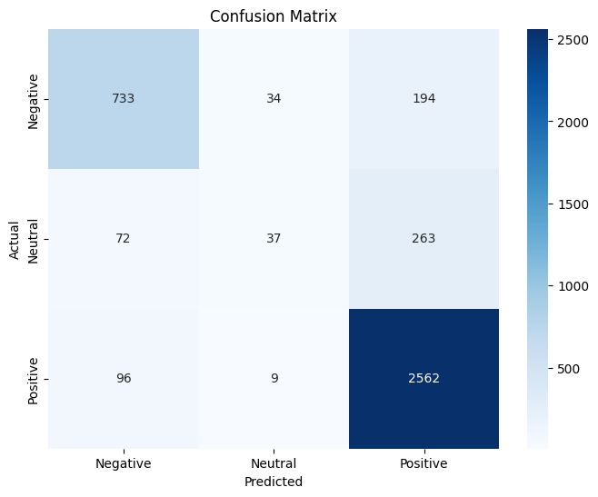

```python
cm = confusion_matrix(y_test, y_test_pred)

plt.figure(figsize=(8, 6))
sns.heatmap(cm, annot=True, fmt="d", cmap="Blues",
            xticklabels=["Negative", "Neutral", "Positive"],
            yticklabels=["Negative", "Neutral", "Positive"])
plt.xlabel("Predicted")
plt.ylabel("Actual")
plt.title("Confusion Matrix")
plt.show()
```

**AUC CURVE FOR TRAINING DATA**

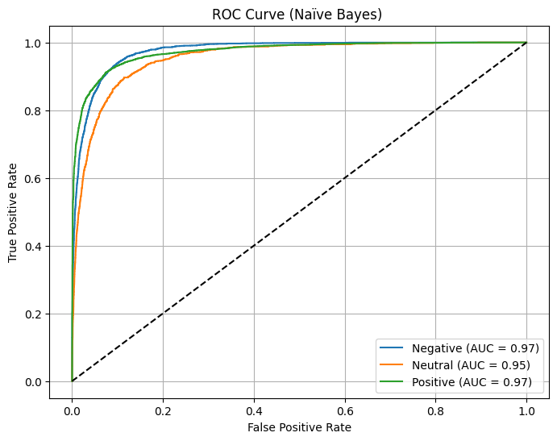

```python
plt.figure(figsize=(8, 6))
for i, label in enumerate(["Negative", "Neutral", "Positive"]):
    fpr, tpr, _ = roc_curve(y_train_bin[:, i], y_train_prob[:, i])
    plt.plot(fpr, tpr, label=f'{label} (AUC = {auc(fpr, tpr):.2f})')

plt.plot([0, 1], [0, 1], 'k--')  # Random Guess Line
plt.xlabel("False Positive Rate")
plt.ylabel("True Positive Rate")
plt.title("ROC Curve (Naïve Bayes) ")
plt.legend()
plt.grid()
plt.show()
```

**AUC CURVE FOR TESTING DATA**

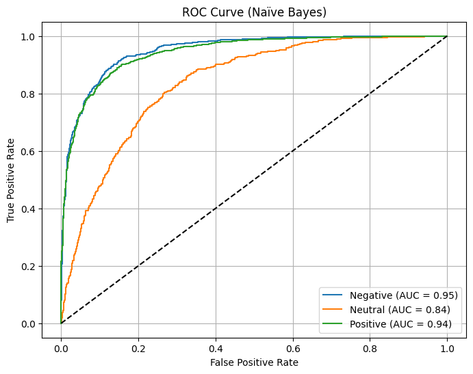

```python
plt.figure(figsize=(8, 6))
for i, label in enumerate(["Negative", "Neutral", "Positive"]):
    fpr, tpr, _ = roc_curve(y_test_bin[:, i], y_prob[:, i])
    plt.plot(fpr, tpr, label=f'{label} (AUC = {auc(fpr, tpr):.2f})')

plt.plot([0, 1], [0, 1], 'k--')  # Random Guess Line
plt.xlabel("False Positive Rate")
plt.ylabel("True Positive Rate")
plt.title("ROC Curve (Naïve Bayes)")
plt.legend()
plt.grid()
plt.show()
```

```python
print("Top Features (Unigrams + Bigrams):\n", vectorizer.get_feature_names_out())
```

```
Top Features (Unigrams + Bigrams):
 ['aa' 'ability' 'able' ... 'zone' 'zoo' 'zucchini']
```

**SAMPLING(SMOTE)**

```python
class_distribution = df['sentiment'].value_counts()
print(class_distribution)
```

```
sentiment
2    13518
0     4600
1     1882
Name: count, dtype: int64
```

```python
smote = SMOTE(random_state=42)
X_train_resampled, y_train_resampled = smote.fit_resample(X_train_tfidf, y_train)
nb_model = MultinomialNB(alpha= 0.1)
nb_model.fit(X_train_resampled, y_train_resampled)
```

```
MultinomialNB(alpha=0.1)
```

```python
y_train_pred = nb_model.predict(X_train_tfidf)

# Testing Accuracy
y_test_pred = nb_model.predict(X_test_tfidf)
y_prob = nb_model.predict_proba(X_test_tfidf)
```

```python
#  Compute Evaluation Metrics
train_accuracy = accuracy_score(y_train, y_train_pred)
test_accuracy = accuracy_score(y_test, y_test_pred)
precision = precision_score(y_test, y_test_pred, average='weighted')
recall = recall_score(y_test, y_test_pred, average='weighted')
report = classification_report(y_test, y_test_pred, output_dict=True)
f1_positive = f1_score(y_test, y_test_pred, average=None)[2]  # F1-score for Positive (label=2)
f1_negative = f1_score(y_test, y_test_pred, average=None)[0]  # F1-score for Negative (label=0)
y_test_bin = label_binarize(y_test, classes=[0, 1, 2])  # Convert labels to binary for AUC
auc_score = roc_auc_score(y_test_bin, y_prob, multi_class='ovr')
```

```python
#  End training time measurement
end_time = time.time()
training_time = end_time - start_time
```

```python
print(f" Naïve Bayes Training Time: {training_time:.2f} seconds")
print(f" Naïve Bayes Accuracy: {train_accuracy:.2f}")
print(f" Naïve Bayes Accuracy: {test_accuracy:.2f}")
print(f" Naïve Bayes Precision: {precision:.2f}")
print(f" Naïve Bayes Recall: {recall:.2f}")
print(f" F1 Score (Positive): {f1_positive:.2f}")
print(f" F1 Score (Negative): {f1_negative:.2f}")
print(f" AUC Score: {auc_score:.2f}")
print("\nNaïve Bayes Classification Report:\n", classification_report(y_test, y_test_pred))
```

```
 Naïve Bayes Training Time: 1.91 seconds
 Naïve Bayes Accuracy: 0.86
 Naïve Bayes Accuracy: 0.79
 Naïve Bayes Precision: 0.83
 Naïve Bayes Recall: 0.79
 F1 Score (Positive): 0.88
 F1 Score (Negative): 0.76
 AUC Score: 0.89

Naïve Bayes Classification Report:
               precision    recall  f1-score   support

           0       0.75      0.77      0.76       961
           1       0.30      0.53      0.39       372
           2       0.94      0.83      0.88      2667

    accuracy                           0.79      4000
   macro avg       0.66      0.71      0.68      4000
weighted avg       0.83      0.79      0.81      4000
```

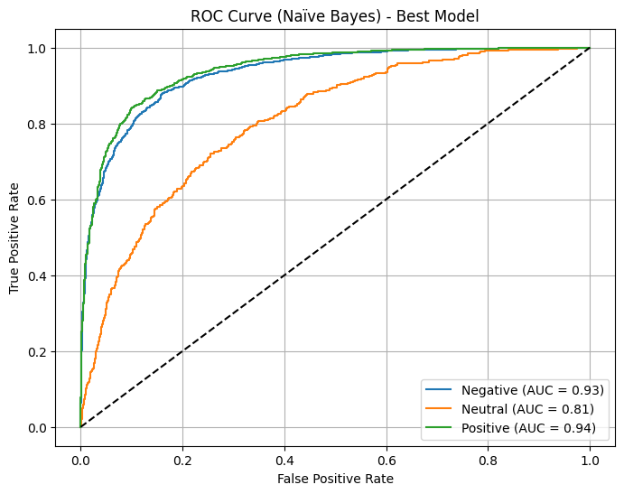

```python
plt.figure(figsize=(8, 6))
for i, label in enumerate(["Negative", "Neutral", "Positive"]):
    fpr, tpr, _ = roc_curve(y_test_bin[:, i], y_prob[:, i])
    plt.plot(fpr, tpr, label=f'{label} (AUC = {auc(fpr, tpr):.2f})')

plt.plot([0, 1], [0, 1], 'k--')  # Random Guess Line
plt.xlabel("False Positive Rate")
plt.ylabel("True Positive Rate")
plt.title("ROC Curve (Naïve Bayes) - Best Model")
plt.legend()
plt.grid()
plt.show()
```

After Sampling, Neutral F1-score improved from 0.16 → 0.39, meaning class balancing helped. Precision improved (0.80 → 0.83), meaning fewer false positives.

**Hyperparameter Tuning**

```python
param_grid = {'alpha': [0.1, 0.5, 1.0, 2.0, 5.0]}
```

```python
nb_model = MultinomialNB(alpha= 0.1)
```

```python
grid_search = GridSearchCV(nb_model, param_grid, cv=4, scoring='accuracy', verbose=1, n_jobs=-1)
```

```python
start_time = time.time()
```

```python
grid_search.fit(X_train_resampled, y_train_resampled)
```

```
Fitting 4 folds for each of 5 candidates, totalling 20 fits
```

```
GridSearchCV(cv=4, estimator=MultinomialNB(alpha=0.1), n_jobs=-1,
             param_grid={'alpha': [0.1, 0.5, 1.0, 2.0, 5.0]},
             scoring='accuracy', verbose=1)
```

```python
training_time = time.time() - start_time
```

```python
best_nb = grid_search.best_estimator_
best_alpha = grid_search.best_params_['alpha']
```

```python
y_train_pred = best_nb.predict(X_train_tfidf)

# Testing Accuracy
y_test_pred = best_nb.predict(X_test_tfidf)
y_prob = best_nb.predict_proba(X_test_tfidf)
```

```python
#  Compute Metrics
train_accuracy = accuracy_score(y_train, y_train_pred)
test_accuracy = accuracy_score(y_test, y_test_pred)
precision = precision_score(y_test, y_test_pred, average='weighted')
recall = recall_score(y_test, y_test_pred, average='weighted')
report = classification_report(y_test, y_test_pred, output_dict=True)
# Extract F1-Scores for Negative (0) and Positive (2) Sentiments
f1_negative = report['0']['f1-score']
f1_positive = report['2']['f1-score']
# Compute Multi-Class AUC
y_test_bin = label_binarize(y_test, classes=[0, 1, 2])  # Convert labels to binary for AUC
auc_score = roc_auc_score(y_test_bin, y_prob, multi_class='ovr')
```

```python
print(f"Best Alpha: {best_alpha}")
print(f"Naïve Bayes Accuracy: {train_accuracy:.2f}")
print(f"Naïve Bayes Accuracy: {test_accuracy:.2f}")
print(f"Naïve Bayes Precision: {precision:.2f}")
print(f"Naïve Bayes Recall: {recall:.2f}")
print(f"Training Time: {training_time:.2f} seconds")
print(f"F1 Score (Negative Sentiment): {f1_negative:.2f}")
print(f"F1 Score (Positive Sentiment): {f1_positive:.2f}")
print(f"AUC Score: {auc_score:.2f}")
print("\nNaïve Bayes Classification Report:\n", classification_report(y_test, y_test_pred))
```

```
Best Alpha: 0.1
Naïve Bayes Accuracy: 0.86
Naïve Bayes Accuracy: 0.79
Naïve Bayes Precision: 0.83
Naïve Bayes Recall: 0.79
Training Time: 1.67 seconds
F1 Score (Negative Sentiment): 0.76
F1 Score (Positive Sentiment): 0.88
AUC Score: 0.89

Naïve Bayes Classification Report:
               precision    recall  f1-score   support

           0       0.75      0.77      0.76       961
           1       0.30      0.53      0.39       372
           2       0.94      0.83      0.88      2667

    accuracy                           0.79      4000
   macro avg       0.66      0.71      0.68      4000
weighted avg       0.83      0.79      0.81      4000
```

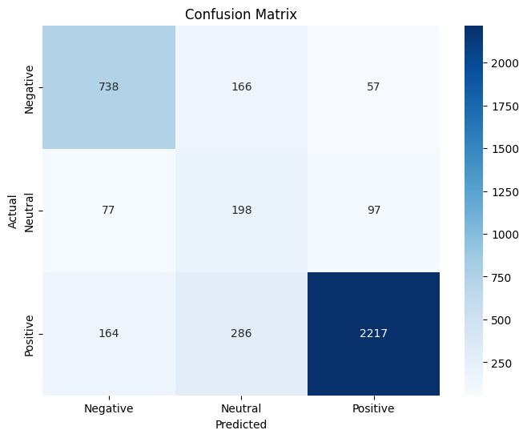

```python
cm = confusion_matrix(y_test, y_test_pred)

plt.figure(figsize=(8, 6))
sns.heatmap(cm, annot=True, fmt="d", cmap="Blues",
            xticklabels=["Negative", "Neutral", "Positive"],
            yticklabels=["Negative", "Neutral", "Positive"])
plt.xlabel("Predicted")
plt.ylabel("Actual")
plt.title("Confusion Matrix")
plt.show()
```

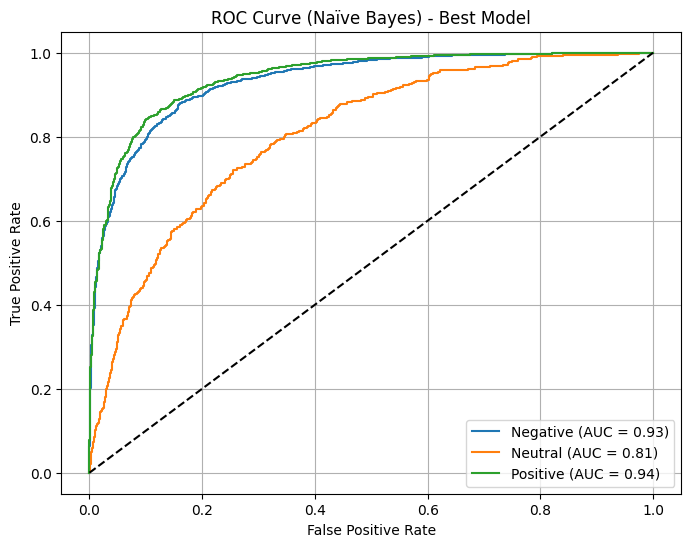

```python
plt.figure(figsize=(8, 6))
for i, label in enumerate(["Negative", "Neutral", "Positive"]):
    fpr, tpr, _ = roc_curve(y_test_bin[:, i], y_prob[:, i])
    plt.plot(fpr, tpr, label=f'{label} (AUC = {auc(fpr, tpr):.2f})')

plt.plot([0, 1], [0, 1], 'k--')  # Random Guess Line
plt.xlabel("False Positive Rate")
plt.ylabel("True Positive Rate")
plt.title("ROC Curve (Naïve Bayes) - Best Model")
plt.legend()
plt.grid()
plt.show()
```

**After Tuning the Model ,** No real improvement over the previous step (sampling effects still present).

Neutral AUC remains at 0.81, meaning hyperparameter tuning alone is not solving the issue.